# PCIT-CoS-Waitlist RCT Paper 1: DECA Attachment

Nancy Briggs

2024-04-29

### DECA Attachment

#### Descriptives

| group | time | n | mean | sd | median | min | max |
| --- | --- | --- | --- | --- | --- | --- | --- |
| 1 | 1 | 30 | 37.70000 | 6.988414 | 37.0 | 28 | 54 |
| 1 | 2 | 22 | 39.13636 | 8.811764 | 35.0 | 28 | 57 |
| 1 | 3 | 19 | 36.89474 | 7.504774 | 34.0 | 28 | 50 |
| 2 | 1 | 27 | 42.03704 | 7.423878 | 42.0 | 28 | 57 |
| 2 | 2 | 11 | 37.45455 | 7.878625 | 35.0 | 28 | 53 |
| 2 | 3 | 5 | 39.40000 | 9.502631 | 35.0 | 29 | 50 |
| 3 | 1 | 30 | 43.56667 | 8.943051 | 42.5 | 28 | 65 |
| 3 | 2 | 26 | 39.65385 | 9.037444 | 37.5 | 28 | 57 |
| 3 | 3 | 0 | NaN | NA | NA | Inf | -Inf |

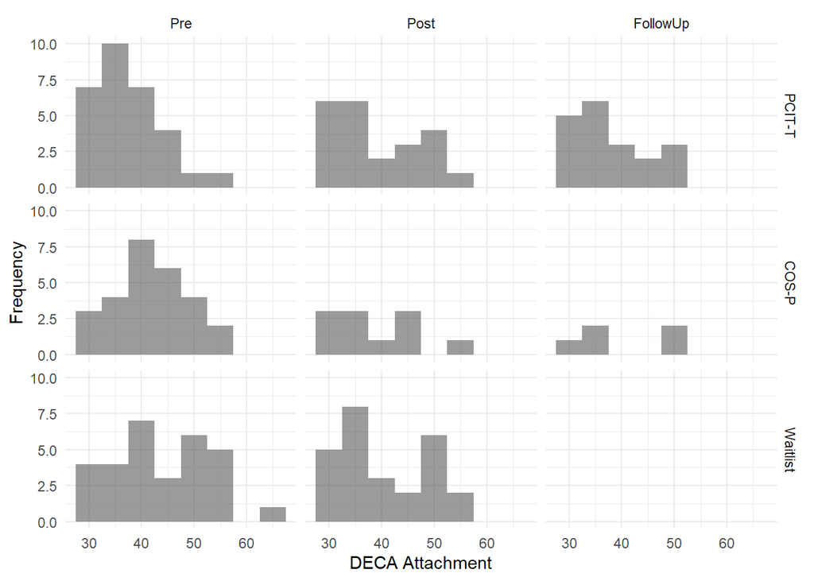

#### Model & Results

A linear mixed model with random effect for individual and fixed effects of group, time and the interaction was run. Estimated marginal means were obtained, and contrasts specified to test Hypothesis 1 and Hypothesis 2.

```
## fixed-effect model matrix is rank deficient so dropping 1 column / coefficient
```

```
## refitting model(s) with ML (instead of REML)
```

|  | Effect | npar | AIC | BIC | logLik | deviance | Chisq | Df | Pr(>Chisq) |
| --- | --- | --- | --- | --- | --- | --- | --- | --- | --- |
| result0 | Intercept | 3 | 1194.354 | 1203.762 | -594.1772 | 1188.354 | NA | NA | NA |
| result1 | Group | 5 | 1192.217 | 1207.896 | -591.1083 | 1182.217 | 6.137796 | 2 | 0.0464723 |
| result2 | Time | 7 | 1191.652 | 1213.602 | -588.8258 | 1177.652 | 4.564998 | 2 | 0.1020289 |
| result3 | Group*Time | 10 | 1193.048 | 1224.406 | -586.5240 | 1173.048 | 4.603497 | 3 | 0.2032423 |

```r
summary(result3)
```

```
## Linear mixed model fit by REML. t-tests use Satterthwaite's method [
## lmerModLmerTest]
## Formula: outcome ~ group * time + (1 | id)
##    Data: dat
##
## REML criterion at convergence: 1149.3
##
## Scaled residuals:
##      Min       1Q   Median       3Q      Max
## -1.74965 -0.67210 -0.08201  0.56214  2.20891
##
## Random effects:
##  Groups   Name        Variance Std.Dev.
##  id       (Intercept) 26.94    5.190
##  Residual             40.24    6.343
## Number of obs: 170, groups:  id, 87
##
## Fixed effects:
##              Estimate Std. Error      df t value Pr(>|t|)
## (Intercept)    37.700      1.496 136.893  25.194  < 2e-16 ***
## group2          4.337      2.174 136.893   1.995  0.04805 *
## group3          5.867      2.116 136.893   2.772  0.00634 **
## time2           1.172      1.832  90.572   0.640  0.52408
## time3          -1.555      1.931  92.629  -0.805  0.42262
## group2:time2   -4.828      3.057 101.223  -1.580  0.11734
## group3:time2   -4.888      2.516  88.269  -1.943  0.05518 .
## group2:time3   -1.683      3.927 106.801  -0.428  0.66916
## ---
## Signif. codes:  0 '***' 0.001 '**' 0.01 '*' 0.05 '.' 0.1 ' ' 1
##
## Correlation of Fixed Effects:
##             (Intr) group2 group3 time2  time3  grp2:2 grp3:2
## group2      -0.688
## group3      -0.707  0.487
## time2       -0.489  0.337  0.346
## time3       -0.464  0.319  0.328  0.424
## group2:tim2  0.293 -0.426 -0.207 -0.599 -0.254
## group3:tim2  0.356 -0.245 -0.504 -0.728 -0.309  0.437
## group2:tim3  0.228 -0.332 -0.161 -0.208 -0.492  0.298  0.152
## fit warnings:
## fixed-effect model matrix is rank deficient so dropping 1 column / coefficient
```

#### Estimated Means & Change

Estimated means for each Treatment and Time are presented. In addition, within-group change between time points is presented with 95% CIs.

##### Group mean difference at each timepoint

Effect sizes all calculated by the pooled T1 SD of the outcome. Adjusted p-value from Bonferroni correction.

Group Differences at Each Time Point

| Group Difference | Time | Mean | SE | t | p | adj p | Lower CL | Upper CL | Effect Size | Lower CL | Upper CL |
| --- | --- | --- | --- | --- | --- | --- | --- | --- | --- | --- | --- |
| 1 - 2 | 1 | -4.337 | 2.174 | -1.995 | 0.117 | 0.144 | -9.489 | 0.815 | -0.603 | -0.718 | -0.718 |
| 1 - 3 | 1 | -5.867 | 2.116 | -2.772 | 0.017 | 0.019 | -10.881 | -0.852 | -0.815 | -0.984 | -0.984 |
| 2 - 3 | 1 | -1.530 | 2.174 | -0.704 | 0.762 | 1.000 | -6.681 | 3.622 | -0.213 | -0.266 | -0.266 |
| 1 - 2 | 2 | 0.491 | 2.913 | 0.169 | 0.984 | 1.000 | -6.399 | 7.381 | 0.068 | -0.114 | -0.114 |
| 1 - 3 | 2 | -0.979 | 2.337 | -0.419 | 0.908 | 1.000 | -6.511 | 4.554 | -0.136 | -0.632 | -0.632 |
| 2 - 3 | 2 | -1.469 | 2.845 | -0.517 | 0.863 | 1.000 | -8.199 | 5.260 | -0.204 | -0.518 | -0.518 |
| 1 - 2 | 3 | -2.654 | 3.830 | -0.693 | 0.768 | 1.000 | -11.719 | 6.410 | -0.369 | 0.345 | 0.345 |
| 1 - 3 | 3 | NA | NA | NA | NA | NA | NA | NA | NA | NA | NA |
| 2 - 3 | 3 | NA | NA | NA | NA | NA | NA | NA | NA | NA | NA |

* Effect size scaled by pooled T1 SD  
† ES 95% Bootstrapped Percentile CI limits  
‡ If you want a positive ES (and it is calculated as negative), be sure to switch the signs and positions of the lower and upper CIs.

##### Change within each group

Within-Group Change and Effect Sizes

| Change | Group | Mean | SE | t | p | adj p | Lower CL | Upper CL | Effect Size | Lower CL | Upper CL |
| --- | --- | --- | --- | --- | --- | --- | --- | --- | --- | --- | --- |
| 1 - 2 | 1 | -1.172 | 1.836 | -0.638 | 0.799 | 1.000 | -5.546 | 3.203 | -0.163 | -0.054 | -0.054 |
| 1 - 3 | 1 | 1.555 | 1.936 | 0.803 | 0.702 | 1.000 | -3.057 | 6.167 | 0.216 | -0.164 | -0.164 |
| 2 - 3 | 1 | 2.727 | 2.024 | 1.347 | 0.373 | 0.545 | -2.102 | 7.556 | 0.379 | -0.110 | -0.110 |
| 1 - 2 | 2 | 3.656 | 2.460 | 1.487 | 0.301 | 0.420 | -2.189 | 9.502 | 0.508 | 0.550 | 0.550 |
| 1 - 3 | 2 | 3.238 | 3.443 | 0.940 | 0.616 | 1.000 | -4.941 | 11.417 | 0.450 | 0.900 | 0.900 |
| 2 - 3 | 2 | -0.418 | 3.696 | -0.113 | 0.993 | 1.000 | -9.211 | 8.374 | -0.058 | 0.350 | 0.350 |
| 1 - 2 | 3 | 3.716 | 1.726 | 2.154 | 0.085 | 0.102 | -0.399 | 7.832 | 0.516 | 0.298 | 0.298 |
| 1 - 3 | 3 | NA | NA | NA | NA | NA | NA | NA | NA | NA | NA |
| 2 - 3 | 3 | NA | NA | NA | NA | NA | NA | NA | NA | NA | NA |

* Effect size scaled by pooled T1 SD  
† ES 95% Bootstrapped Percentile CI limits  
‡ If you want a positive ES (and it is calculated as negative), be sure to switch the signs and positions of the lower and upper CIs.

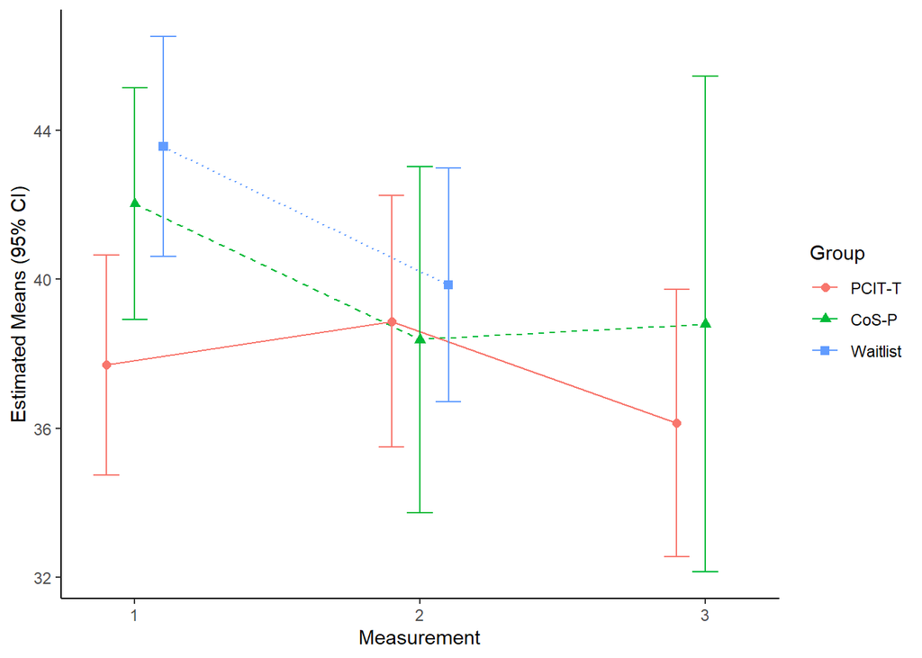

#### Hypothesis 1

We hypothesize that from baseline (‘T1’) to post-treatment/waitlist (‘T2’) there will be a gradient effect, whereby parent-child dyads who receive PCIT-T will show the greatest gains and parent-child dyads who receive no treatment will show the least gains. For the outcome, then, the null hypothesis is:

$H_0: \text {mean change}(\text{PCIT-T}) = \text {mean change}(\text{CoS-P}) = \text {mean change}(\text{Waitlist})$ $H_A: \text {mean change}(\text{PCIT-T}) > \text {mean change}(\text{CoS-P}) > \text {mean change}(\text{Waitlist})$

This is a joint hypothesis test.

First, confirming that the ordering of the means is as hypothesized:

```
## group = 1:
##  contrast estimate   SE    df t.ratio p.value
##  1 - 2      -1.172 1.84  90.7  -0.638  0.7995
##  1 - 3       1.555 1.94  92.7   0.803  0.7020
##  2 - 3       2.727 2.02  85.3   1.347  0.3734
##
## group = 2:
##  contrast estimate   SE    df t.ratio p.value
##  1 - 2       3.656 2.46 107.6   1.487  0.3014
##  1 - 3       3.238 3.44 111.7   0.940  0.6160
##  2 - 3      -0.418 3.70 100.8  -0.113  0.9930
##
## group = 3:
##  contrast estimate   SE    df t.ratio p.value
##  1 - 2       3.716 1.73  85.8   2.154  0.0852
##  1 - 3      nonEst   NA    NA      NA      NA
##  2 - 3      nonEst   NA    NA      NA      NA
##
## Degrees-of-freedom method: kenward-roger
## P value adjustment: tukey method for comparing a family of 3 estimates
```

Now, to get the p-value associated with the joint hypothesis.

```
##   (Intercept) group2 group3 time2 time3 group2:time2 group3:time2 group2:time3
## 1           0      0      0     0     0           -1            0            0
## 2           0      0      0     0     1            0            1            0
```

```
##
##   General Linear Hypotheses
##
## Linear Hypotheses:
##        Estimate
## 1 == 0    4.828
## 2 == 0   -6.443
##
## Global Test:
##       F DF1 DF2  Pr(>F)
## 1 3.495   2 160 0.03269
```

p<0.05, but the pattern of change is not as we predicted.That is PCITT showed an increase T1 to T2, and COSP showed a decrease.

#### Hypothesis 2

##### Change from T2-T3

There will be a gradient of size of change from T2 to T3 such that the change in the PCIT-T group > the change in the CoS-P group. This isn’t really a gradient; it’s just 1 hypothesis.

First, the change in PCITT and COSP from time 2 to time 3:

```
## group = 1:
##  time emmean   SE  df lower.CL upper.CL
##  1      37.7 1.50 137     34.7     40.7
##  2      38.9 1.71 154     35.5     42.3
##  3      36.1 1.82 159     32.6     39.7
##
## group = 2:
##  time emmean   SE  df lower.CL upper.CL
##  1      42.0 1.58 137     38.9     45.2
##  2      38.4 2.36 162     33.7     43.0
##  3      38.8 3.37 145     32.1     45.5
##
## group = 3:
##  time emmean   SE  df lower.CL upper.CL
##  1      43.6 1.50 137     40.6     46.5
##  2      39.9 1.59 146     36.7     43.0
##  3    nonEst   NA  NA       NA       NA
##
## Degrees-of-freedom method: kenward-roger
## Confidence level used: 0.95
```

```
## group = 1:
##  contrast estimate   SE    df lower.CL upper.CL
##  1 - 2      -1.172 1.84  90.7   -5.546     3.20
##  1 - 3       1.555 1.94  92.7   -3.057     6.17
##  2 - 3       2.727 2.02  85.3   -2.102     7.56
##
## group = 2:
##  contrast estimate   SE    df lower.CL upper.CL
##  1 - 2       3.656 2.46 107.6   -2.189     9.50
##  1 - 3       3.238 3.44 111.7   -4.941    11.42
##  2 - 3      -0.418 3.70 100.8   -9.211     8.37
##
## group = 3:
##  contrast estimate   SE    df lower.CL upper.CL
##  1 - 2       3.716 1.73  85.8   -0.399     7.83
##  1 - 3      nonEst   NA    NA       NA       NA
##  2 - 3      nonEst   NA    NA       NA       NA
##
## Degrees-of-freedom method: kenward-roger
## Confidence level used: 0.95
## Conf-level adjustment: tukey method for comparing a family of 3 estimates
```

```r
## Specify contrast matrices
# Hyp1 is 1 df test
# could use alternative="less" ir alternative="greater" in glht
hyp2   <- matrix(c(0, 0,0, 0,0, -1,0,1 ),1)
hyp2F <- glht(result3, linfct = hyp2)
summary(hyp2F)
```

```
##
##   Simultaneous Tests for General Linear Hypotheses
##
## Fit: lmer(formula = outcome ~ group * time + (1 | id), data = dat)
##
## Linear Hypotheses:
##        Estimate Std. Error z value Pr(>|z|)
## 1 == 0    3.145      4.196    0.75    0.454
## (Adjusted p values reported -- single-step method)
```

```r
s<-summary(hyp2F, test = Ftest())
#also see this webpage for more on contrasts https://rcompanion.org/rcompanion/h_01.html



## Extract pvaue for evidence / no evidence
evidence = ifelse(s$test$pvalue<0.05, "evidence", "no evidence")
```

Change in G1 from T2 to T3: 2.727

Change in G2 from T2 to T3: -0.418

##### Change from T1-T3

```
##
##   General Linear Hypotheses
##
## Linear Hypotheses:
##        Estimate
## 1 == 0   -1.683
##
## Global Test:
##        F DF1 DF2 Pr(>F)
## 1 0.1836   1 160 0.6689
```

Change in G1 from T1 to T3: 1.555

Change in G2 from T1 to T3: 3.238

p=0.6689. We have no evidence that the change from T1 to T3 is different for G1 and G2

#### Residuals

Assumptions of the model are met.

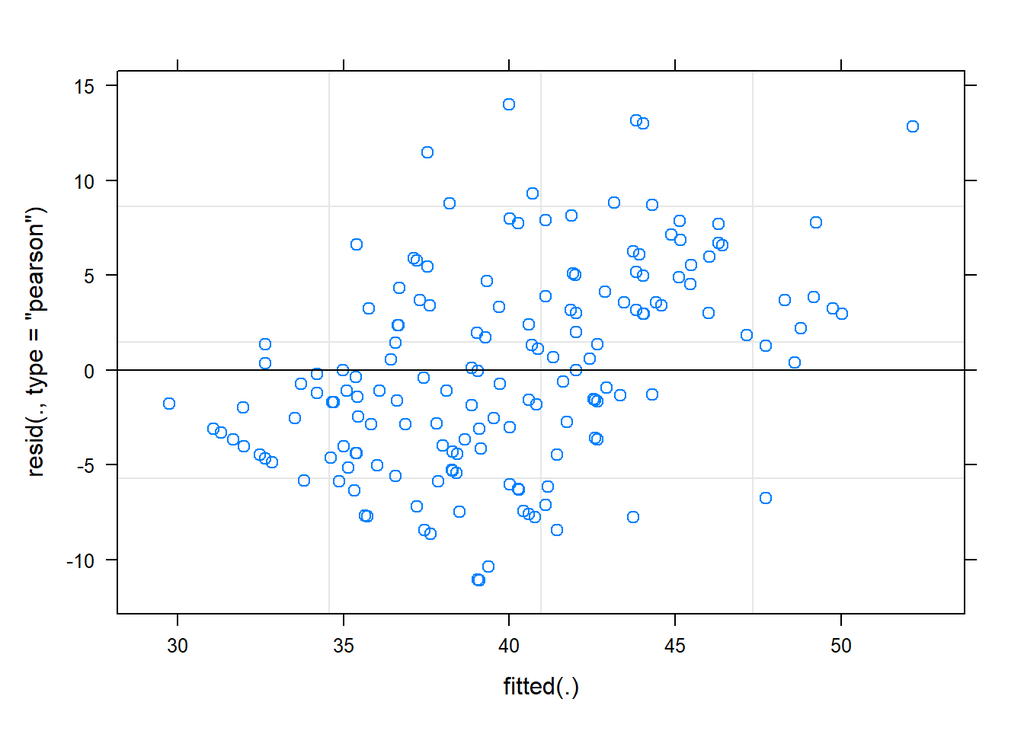

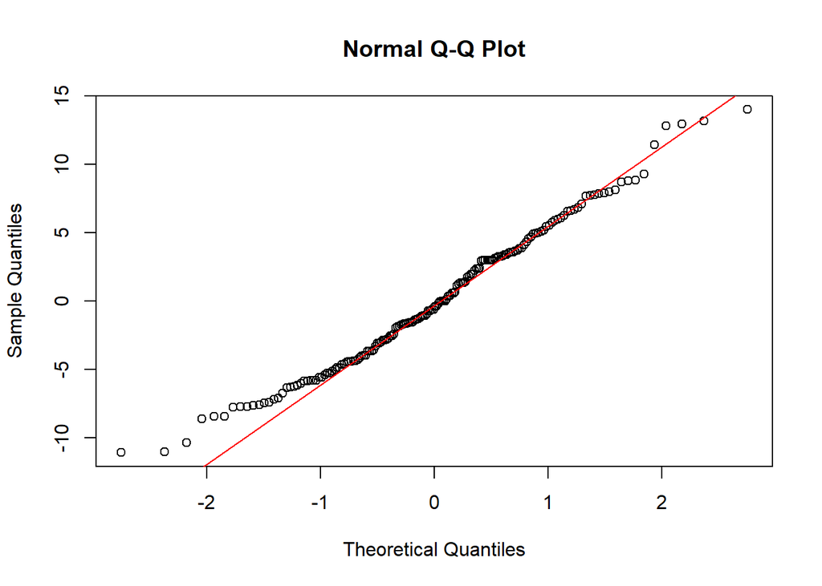

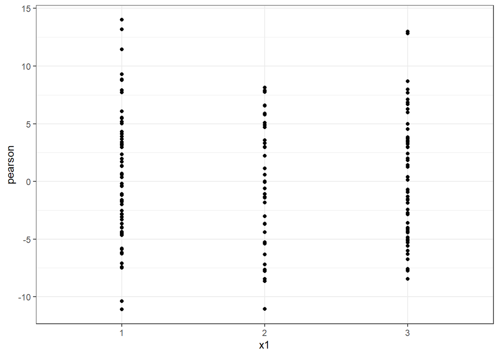

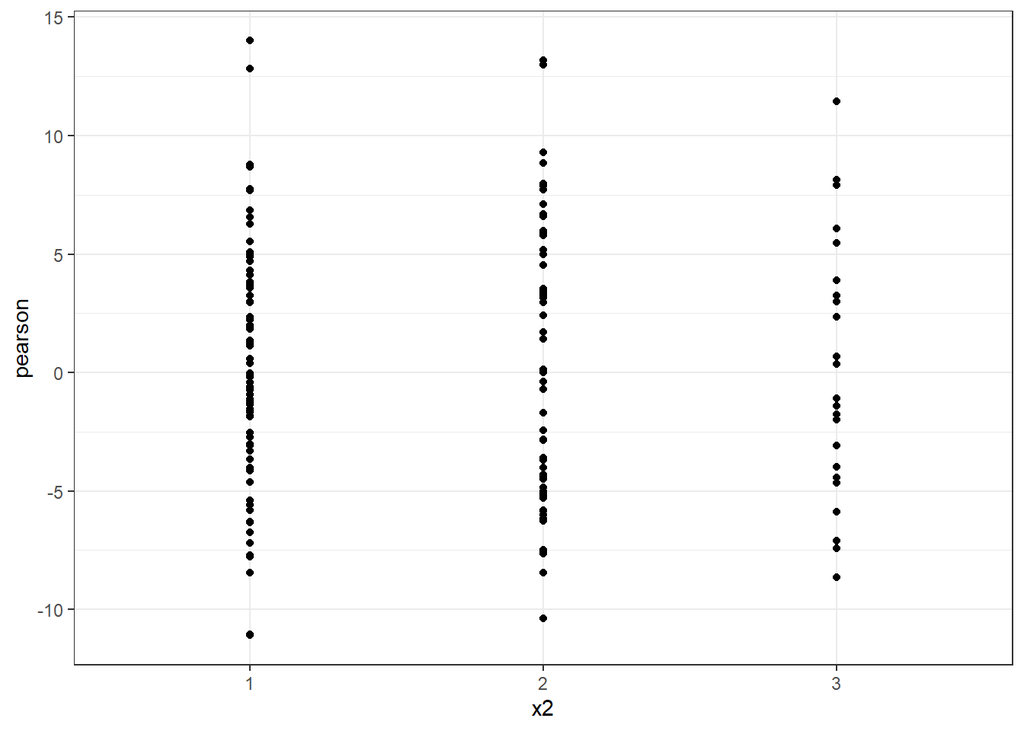

```r
rm(list = ls())
```